# Women of 2020

```r
library(ggplot2)
library(dplyr)
library(magrittr)

library(igraph)
library(ggraph)
```

This week’s data comes from the BBC.

```r
women <- readr::read_csv('https://raw.githubusercontent.com/rfordatascience/tidytuesday/master/data/2020/2020-12-08/women.csv')
```

The data is fairly simple; just name, image, award category, country of residence, role/career, and a description of the women and their achievements.

```r
women %>%
  skimr::skim()
```

```
-- Data Summary ------------------------
                           Values
Name                       Piped data
Number of rows             100
Number of columns          6
_______________________
Column type frequency:
  character                6
________________________
Group variables            None

-- Variable type: character ------------------------------------------------------
# A tibble: 6 x 8
  skim_variable n_missing complete_rate   min   max empty n_unique whitespace
* <chr>             <int>         <dbl> <int> <int> <int>    <int>      <int>
1 name                  0             1     5    28     0      100          0
2 img                   0             1    80   103     0      100          0
3 category              0             1     3    10     0        5          0
4 country               0             1     2    46     0       65          0
5 role                  0             1     4    38     0       75          0
6 description           0             1    59   396     0      100          0
```

There are exactly 100 observations, including one blank observation (“Unsung Hero,” in observance of all the women who made a difference in 2020 but could not be fit on the list). Visualizing this type of data is not my strong suit. It focuses more on aesthetics than I’m used to. Put another way, the data can’t tell me which visualization to use. Although that’s not necessarily true. But there’s no network, no obvious relationships between the women, and not much data. Let’s take a look at some of the variables, though, to get a sense.

| name | img | category | country | role | description |
| --- | --- | --- | --- | --- | --- |
| Unsung hero | https://ichef.bbci.co.uk/news/300/cpsprodpb/F288/production/_115588026_100_women_2020_unsung.png | All | Worldwide | Making a difference | In an extraordinary year, when countless women around the world have made a sacrifice to help others, the first place on the list is left open to acknowledge their work and to remember those who have … |
| Loza Abera Geinore | https://ichef.bbci.co.uk/news/300/cpsprodpb/15ABB/production/_115336788_loza_abera.jpg | Leadership | Ethiopia | Footballer | Loza Abera Geinore was born and raised in a small town in southern Ethiopia. She played for Hawassa City SC in the Ethiopian Women's Premier League for two seasons, during which time she became the cl… |
| Houda Abouz | https://ichef.bbci.co.uk/news/300/cpsprodpb/147BF/production/_115330938_houda_abouz.jpg | Creativity | Morocco | Rapper | Houda Abouz, aka Khtek, is a Moroccan rapper known for her unique style and lyrical songs. |
| Christina Adane | https://ichef.bbci.co.uk/news/300/cpsprodpb/4A81/production/_115337091_christina_adane_copy.jpg | Leadership | Netherlands | Campaigner | Christina was behind the UK petition for free school meals over the summer holidays, which footballer Marcus Rashford supported. |
| Yvonne Aki-Sawyerr | https://ichef.bbci.co.uk/news/300/cpsprodpb/13F95/production/_115331818_yvonne_aki-sawyerr.jpg | Leadership | Sierra Leone | Mayor | Mayor Yvonne Aki-Sawyerr OBE is best known for her Transform Freetown plan, which targets 11 sectors – from tackling environmental degradation and climate change to helping create jobs in order to red… |
| Rina Akter | https://ichef.bbci.co.uk/news/300/cpsprodpb/9DDD/production/_115331404_rina_akter.jpg | Knowledge | Bangladesh | Former sex worker | During the pandemic, Rina and her team of helpers have served around 400 meals a week - including rice, vegetables, eggs and meat - to sex workers in Dhaka who have found themselves without clients, a… |
| Sarah Al-Amiri | https://ichef.bbci.co.uk/news/300/cpsprodpb/E2D9/production/_115337085_he_sarah_alamiri.jpg | Knowledge | UAE | Minister for Advanced Technologies | Her Excellency Sarah Al-Amiri is UAE Minister of State for Advanced Technologies and chairs the UAE Space Agency. She was previously science lead and deputy project manager for the Emirates Mars Missi… |
| Waad al-Kateab | https://ichef.bbci.co.uk/news/300/cpsprodpb/11885/production/_115331817_waad_al-kateab.jpg | Creativity | Syria | Film-maker | Waad al-Kateab is a Syrian activist, journalist and award-winning film-maker who has received numerous accolades (including an Emmy) for her news reports in Aleppo. In 2020 her first feature, For Sama… |
| Adriana Albini | https://ichef.bbci.co.uk/news/300/cpsprodpb/1612D/production/_115331409_adriana_albini.jpg | Knowledge | Italy | Pathologist | Adriana Albini is head of the vascular biology and angiogenesis laboratory of IRCCS MultiMedica, and of the MultiMedica Foundation; professor of general pathology at the University of Milan-Bicocca an… |
| Ubah Ali | https://ichef.bbci.co.uk/news/300/cpsprodpb/166A5/production/_115331819_ubah_ali.jpg | Leadership | Somaliland | FGM educator | Ubah Ali is a co-founder of Solace for Somaliland Girls, a foundation committed to eradicating all forms of female genital mutilation (FGM) across communities in Somaliland, through education and empo… |

A long description variable lends itself to text analysis, and the spiky area of ‘what makes a winner a winner,’ a problem fraught with danger because (among other things no doubt) it lacks a counterfactual. A better visualization might break down the winners by category or role. Probably there aren’t enough roles in common, but there are only five unique categories.

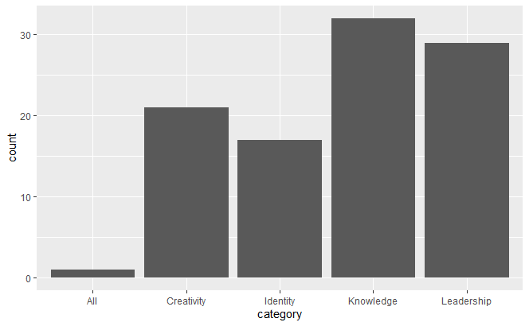

In fact, there are only five categories, and one is ‘All’, which contains one representative: the unsung hero. Well, a nice network could show the way things are related. There are 75 roles, so only a couple repeat. Let’s see.

```r
women %>%
  janitor::tabyl(role) %>%
  slice_max(order_by = percent, n = 10)
```

```
                   role n percent
               Activist 6    0.06
             Campaigner 4    0.04
    Disability activist 4    0.04
               Musician 3    0.03
              Scientist 3    0.03
                  Actor 2    0.02
       Climate activist 2    0.02
                 Doctor 2    0.02
 Environmental activist 2    0.02
             Film-maker 2    0.02
  Human-rights activist 2    0.02
  Human rights activist 2    0.02
                  Mayor 2    0.02
                Teacher 2    0.02
                 Writer 2    0.02
```

So, six activists, four campaigners and disability activists (resp.), three musicians and scientists (resp.) and a few pairs of things. There are many types of activist, so I could pull that out.

I guess I’m envisioning a graph, maybe a tree. At the center is the ‘All’ category, which breaks down into the other four categories, each of which breaks down into another subcategory, and finally we reach the people themselves. It would work as a treemap, even though that wouldn’t be as visually nice as a well laid-out network. Let me look around to see what options I have.

Scroll nearly to the bottom of this [{ggraph}](https://www.data-imaginist.com/2017/ggraph-introduction-layouts/) page, and you’ll see an example of the kind of tree I want to make. There’s circle-packing, and circle-packing but the circles are dots and connected by lines. I’m not sure how to make the data for this, though.

It should be basic to create a one-level dataset with `igraph` that I can turn into the most basic type of packed circles. Example:

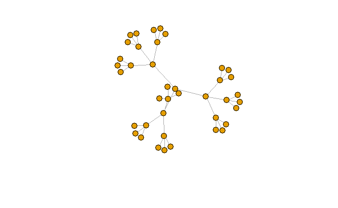

How do I turn my data into this type of graph? I need just three levels at first.

1. Top 100 women, center
2. Categories (all, creativity, identity, knowledge, leadership)
3. People

A basic blueprint is:

```
from        to
women       all
women       creativity
...
women       leadership
all         Unsung Hero
creativity  Individual 1
creativity  Individual 2
...
leadership  Individual 99
```

Then, set the name of the chart to ‘Tree’ for good measure, assign attributes later.

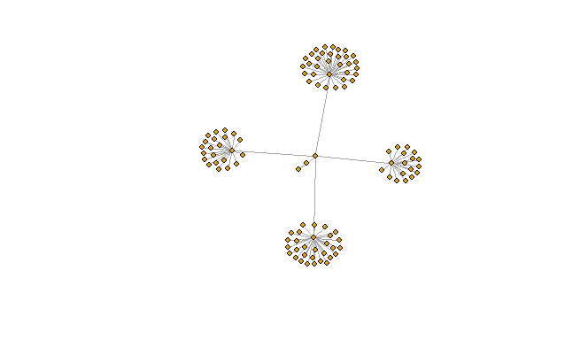

Now I can try to plot the packed circles with ggraph.

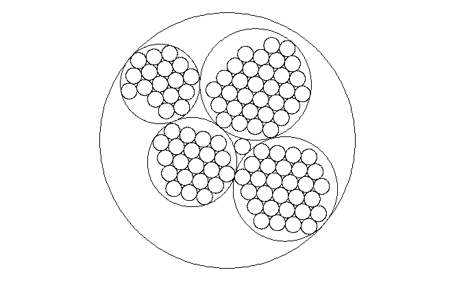

Oh neat.

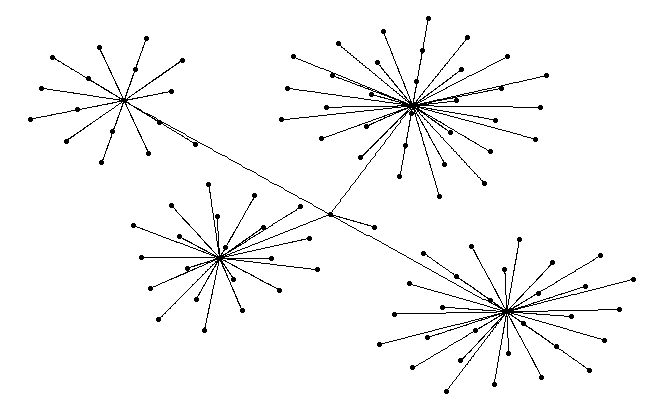

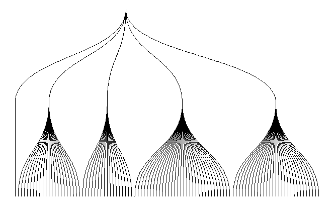

In the last graph, how would I add names to the bottom of the graph? (NOTE: since this is not a dendrogram, it could be made in `ggplot` with `ggbump::geom_sigmoid`).

First things first, let’s add some attributes. To do this, you pass another data frame to `graph_from_data_frame` via the argument ‘vertices’. This contains one entry for every vertex (from 1 to n) and variables for their attributes. All vertices have names, and in this case they are the names of the groups.

```r
women_graph_lvl1 <- data.frame(
  name = "BBC 100 Women",
  level = 1,
  category = NA
)

women_graph_lvl2 <- women %>%
  select(name = category) %>% unique() %>%
  mutate(level = 2, category = NA)

women_graph_lvl3 <- women %>%
  select(name, category) %>%
  mutate(
    level = 3
  )

women_graph_df <- women %>%
  mutate(from = "BBC 100 Women") %>%
  select(from, to = category) %>%
  unique() %>%
  rbind(select(women, from = category, to = name)) %>%
  arrange(from)

women_graph_vertices <- rbind(women_graph_lvl1, women_graph_lvl2, women_graph_lvl3)


women_graph <- graph_from_data_frame(
  d = women_graph_df,
  vertices = women_graph_vertices,
)
```

This gives me complete control over the vertex attributes. I haven’t found as concise a method for making the graph data frame yet. This current method seems ok for now.